# LME Analysis of PNs

Antoin Rodgers

18.05.2022

## L targets

### Analysis of L timing

- intercepts only model
- trim: +/- residual sd > 3

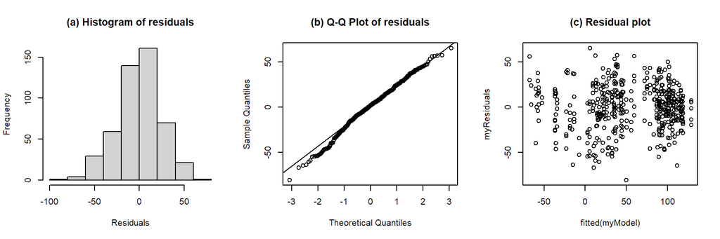

```
## Formula:  l_t ~ acc_phon + ana_syls + foot_syls + wrd_end_syl + pn_new_word + gender + (1 | speaker) + (1 | pn_str_syl) + (1 | nuc_pre_text)
##
## Linear mixed model fit by REML. t-tests use Satterthwaite's method [
## lmerModLmerTest]
## Formula: l_t_equation
##    Data: pn_l_t.trimmed
## Control:
## lmerControl(optimizer = optimizer, calc.derivs = FALSE, optCtrl = list(method = "nlminb",
##     starttests = FALSE, kkt = FALSE))
##
## REML criterion at convergence: 4479.4
##
## Scaled residuals:
##     Min      1Q  Median      3Q     Max
## -3.2428 -0.5630  0.0651  0.6318  2.6099
##
## Random effects:
##  Groups       Name        Variance Std.Dev.
##  nuc_pre_text (Intercept) 1024.0   32.00
##  speaker      (Intercept)  110.8   10.53
##  pn_str_syl   (Intercept)  931.2   30.52
##  Residual                  619.4   24.89
## Number of obs: 486, groups:  nuc_pre_text, 12; speaker, 11; pn_str_syl, 8
##
## Fixed effects:
##                 Estimate Std. Error      df t value Pr(>|t|)
## (Intercept)       82.342     40.607   4.075   2.028  0.11120
## acc_phonL*        24.835      9.599 468.890   2.587  0.00998 **
## ana_syls1        -52.504     48.503   4.843  -1.082  0.32997
## ana_syls2        -23.045     62.254   4.258  -0.370  0.72893
## ana_syls3        -12.484     62.271   4.263  -0.200  0.85031
## foot_syls2       -10.580     40.799   2.847  -0.259  0.81301
## foot_syls3        18.454     42.485   2.697   0.434  0.69639
## foot_syls4        57.970     48.216   3.890   1.202  0.29729
## wrd_end_syl2     -32.022     20.877  25.780  -1.534  0.13726
## wrd_end_syl3     -37.628     23.760  40.615  -1.584  0.12102
## pn_new_wordTRUE    4.307     50.410   4.889   0.085  0.93531
## genderM          -70.861      6.955   9.848 -10.188 1.51e-06 ***
## ---
## Signif. codes:  0 '***' 0.001 '**' 0.01 '*' 0.05 '.' 0.1 ' ' 1
```

[output cut: 41 more lines]

```
##
##             Eliminated Sum Sq Mean Sq NumDF  DenDF  F value    Pr(>F)
## pn_new_word          1      5       5     1   4.89   0.0073   0.93531
## foot_syls            2   1932     644     3   3.84   1.0387   0.46886
## ana_syls             3   3889    1296     3   2.00   2.0632   0.34295
## wrd_end_syl          4   4609    2304     2   6.99   3.6455   0.08233 .
## acc_phon             0   4010    4010     1 472.69   6.3934   0.01178 *
## gender               0  63859   63859     1   9.80 101.8020 1.724e-06 ***
## ---
## Signif. codes:  0 '***' 0.001 '**' 0.01 '*' 0.05 '.' 0.1 ' ' 1
##
## Model found:
## l_t ~ acc_phon + gender + (1 | speaker) + (1 | pn_str_syl) + (1 | nuc_pre_text)
##
## isSingular(my_model, tol = 1e-05 ) --> FALSE
```

Anova of model: l_t ~ acc_phon + ana_syls + foot_syls + wrd_end_syl + pn_new_word + gender + (1 | speaker) + (1 | pn_str_syl) + (1 | nuc_pre_text)

| term | sumsq | meansq | NumDF | DenDF | F value | p.value | signif. |
| --- | --- | --- | --- | --- | --- | --- | --- |
| acc_phon | 4146.319 | 4146.319 | 1 | 468.890 | 6.694 | 9.975196e-03 | p<0.01 |
| ana_syls | 3972.653 | 1324.218 | 3 | 4.966 | 2.138 | 2.147113e-01 |  |
| foot_syls | 1762.456 | 587.485 | 3 | 3.153 | 0.948 | 5.132260e-01 |  |
| wrd_end_syl | 1611.618 | 805.809 | 2 | 53.166 | 1.301 | 2.808173e-01 |  |
| pn_new_word | 4.521 | 4.521 | 1 | 4.889 | 0.007 | 9.353069e-01 |  |
| gender | 64293.172 | 64293.172 | 1 | 9.848 | 103.793 | 1.514276e-06 | p<0.001 |

[figure not shown]

Conditional and marginal R<sup>2</sup> of model

| R2_conditional | R2_marginal |
| --- | --- |
| 0.87 | 0.44 |

$acc_phon

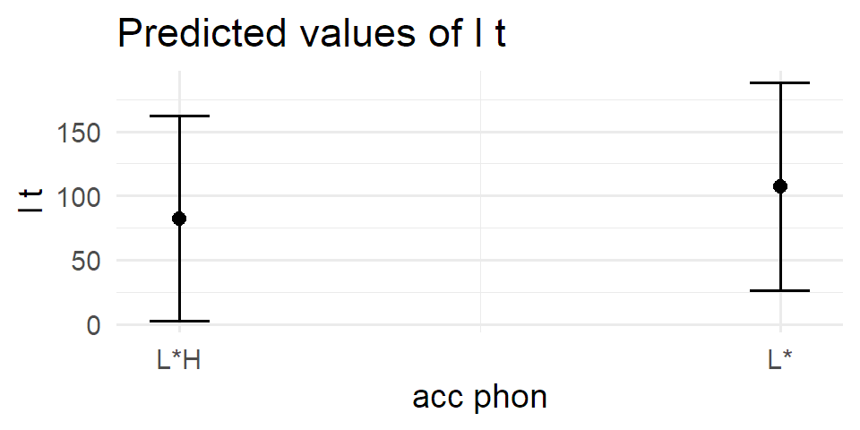

$ana_syls

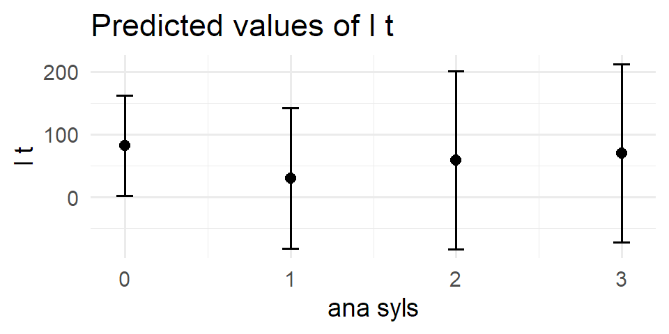

$foot_syls

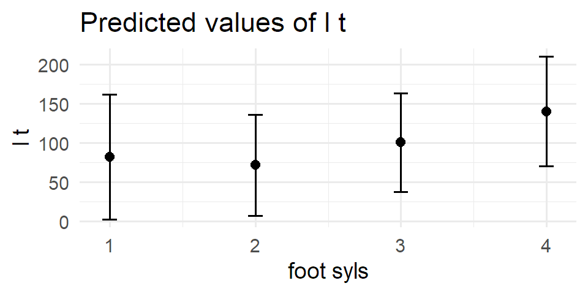

$wrd_end_syl

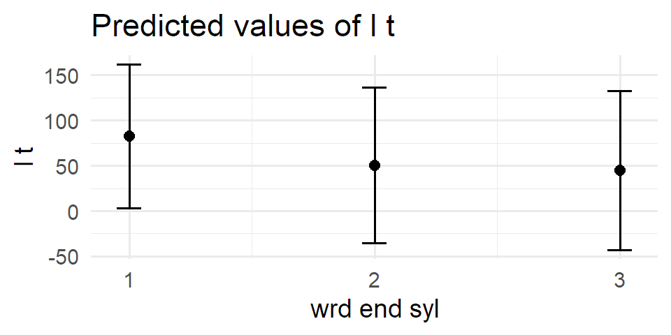

$pn_new_word

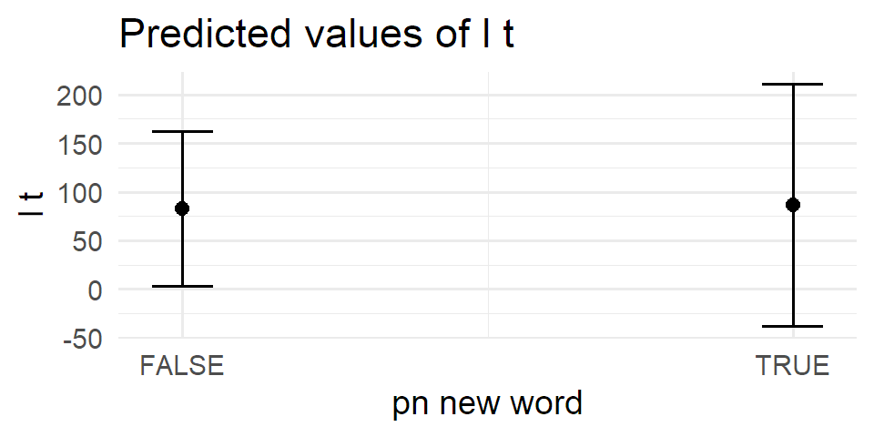

$gender

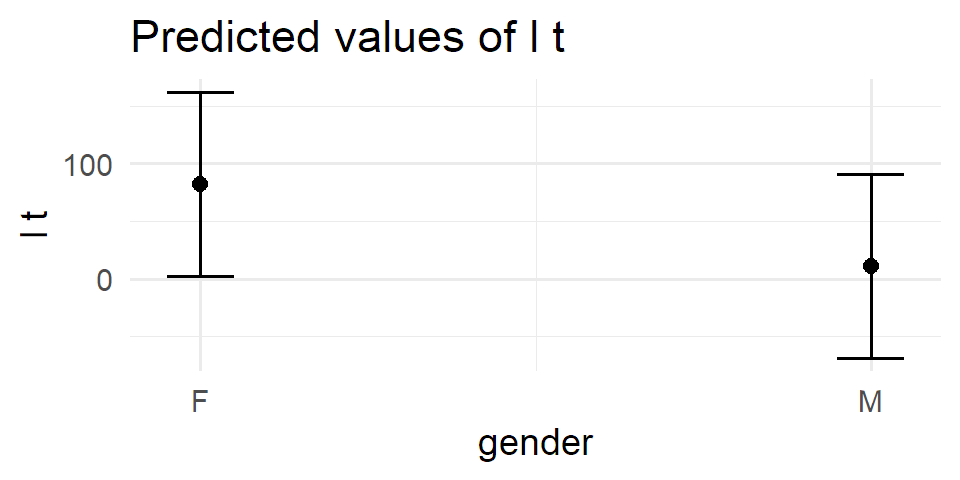

summary of model: l_t ~ acc_phon + ana_syls + foot_syls + wrd_end_syl + pn_new_word + gender + (1 | speaker) + (1 | pn_str_syl) + (1 | nuc_pre_text)

| term | estimate | conf.low | conf.high | std.error | t.value | df | p.value |
| --- | --- | --- | --- | --- | --- | --- | --- |
| (Intercept) | 82.342 | -29.583611 | 194.26837 | 40.607 | 2.028 | 4.08 | 0.1112 |
| acc_phonL* | 24.835 | 5.972345 | 43.69692 | 9.599 | 2.587 | 468.89 | 0.01 |
| ana_syls1 | -52.504 | -178.414584 | 73.40715 | 48.503 | -1.082 | 4.84 | 0.33 |
| ana_syls2 | -23.045 | -191.837605 | 145.74685 | 62.254 | -0.370 | 4.26 | 0.7289 |
| ana_syls3 | -12.484 | -181.251427 | 156.28295 | 62.271 | -0.200 | 4.26 | 0.8503 |
| foot_syls2 | -10.580 | -144.455067 | 123.29604 | 40.799 | -0.259 | 2.85 | 0.813 |
| foot_syls3 | 18.454 | -125.752360 | 162.66014 | 42.485 | 0.434 | 2.70 | 0.6964 |
| foot_syls4 | 57.970 | -77.411624 | 193.35132 | 48.216 | 1.202 | 3.89 | 0.2973 |
| wrd_end_syl2 | -32.022 | -74.954068 | 10.90977 | 20.877 | -1.534 | 25.78 | 0.1373 |
| wrd_end_syl3 | -37.628 | -85.625137 | 10.36971 | 23.760 | -1.584 | 40.61 | 0.121 |
| pn_new_wordTRUE | 4.307 | -126.170136 | 134.78327 | 50.410 | 0.085 | 4.89 | 0.9353 |
| genderM | -70.861 | -86.390812 | -55.33084 | 6.955 | -10.188 | 9.85 | 1.5e-06 |

b0 for l_t ~ acc_phon + ana_syls + foot_syls + wrd_end_syl + pn_new_word + gender + (1 | speaker) + (1 | pn_str_syl) + (1 | nuc_pre_text)

| intercept | estimate | conf.low | conf.high | std.error | t.value | df | p.value |
| --- | --- | --- | --- | --- | --- | --- | --- |
| ana_syls0 | 82.3 | -29.6 | 194.3 | 40.61 | 2.03 | 4.08 | 0.111 |
| ana_syls1 | 29.8 | -123.3 | 183 | 57.02 | 0.52 | 4.37 | 0.626 |
| ana_syls2 | 59.3 | -145.6 | 264.2 | 72.35 | 0.82 | 3.81 | 0.461 |
| ana_syls3 | 69.9 | -135 | 274.7 | 72.36 | 0.97 | 3.81 | 0.392 |
| foot_syls1 | 82.3 | -29.6 | 194.3 | 40.61 | 2.03 | 4.08 | 0.111 |
| foot_syls2 | 71.8 | -12.9 | 156.4 | 32.89 | 2.18 | 4.98 | 0.081 |
| foot_syls3 | 100.8 | 19.9 | 181.7 | 32.08 | 3.14 | 5.33 | 0.023 |
| foot_syls4 | 140.3 | 56.7 | 223.9 | 35.79 | 3.92 | 7.45 | 0.005 |
| wrd_end_syl1 | 82.3 | -29.6 | 194.3 | 40.61 | 2.03 | 4.08 | 0.111 |
| wrd_end_syl2 | 50.3 | -65.8 | 166.5 | 43.80 | 1.15 | 4.54 | 0.308 |
| wrd_end_syl3 | 44.7 | -72.2 | 161.7 | 44.68 | 1.00 | 4.72 | 0.365 |

b1 for l_t ~ acc_phon + ana_syls + foot_syls + wrd_end_syl + pn_new_word + gender + (1 | speaker) + (1 | pn_str_syl) + (1 | nuc_pre_text)

| intercept | slope | estimate | conf.low | conf.high | std.error | t.value | df | p.value |
| --- | --- | --- | --- | --- | --- | --- | --- | --- |
| ana_syls0 | ana_syls1 | -52.5 | -178.4 | 73.4 | 48.500 | -1.080 | 4.84 | 0.33 |
| ana_syls0 | ana_syls2 | -23 | -191.8 | 145.7 | 62.250 | -0.370 | 4.26 | 0.729 |
| ana_syls0 | ana_syls3 | -12.5 | -181.3 | 156.3 | 62.270 | -0.200 | 4.26 | 0.85 |
| ana_syls1 | ana_syls2 | 29.5 | -110.1 | 169 | 41.540 | 0.710 | 2.74 | 0.534 |
| ana_syls1 | ana_syls3 | 40 | -99.5 | 179.5 | 41.550 | 0.960 | 2.74 | 0.412 |
| ana_syls2 | ana_syls3 | 10.6 | 0.912 | 20.2 | 4.910 | 2.150 | 457.18 | 0.032 |
| foot_syls1 | foot_syls2 | -10.6 | -144.5 | 123.3 | 40.800 | -0.260 | 2.85 | 0.813 |
| foot_syls1 | foot_syls3 | 18.4 | -125.8 | 162.7 | 42.490 | 0.430 | 2.70 | 0.696 |
| foot_syls1 | foot_syls4 | 58 | -77.4 | 193.4 | 48.220 | 1.200 | 3.89 | 0.297 |
| foot_syls2 | foot_syls3 | 29 | -81.4 | 139.5 | 36.380 | 0.800 | 3.28 | 0.479 |
| foot_syls2 | foot_syls4 | 68.6 | -37.8 | 174.9 | 41.300 | 1.660 | 4.97 | 0.158 |
| foot_syls3 | foot_syls4 | 39.5 | -65.8 | 144.8 | 35.850 | 1.100 | 3.51 | 0.34 |
| wrd_end_syl1 | wrd_end_syl2 | -32 | -75 | 10.9 | 20.880 | -1.530 | 25.78 | 0.137 |
| wrd_end_syl1 | wrd_end_syl3 | -37.6 | -85.6 | 10.4 | 23.760 | -1.580 | 40.61 | 0.121 |
| wrd_end_syl2 | wrd_end_syl3 | -5.61 | -28.2 | 17 | 11.510 | -0.490 | 397.73 | 0.626 |
| intercept | acc_phonL* | 24.8 | 5.972 | 43.7 | 9.599 | 2.587 | 468.89 | 0.01 |
| intercept | pn_new_wordTRUE | 4.307 | -126.2 | 134.8 | 50.410 | 0.085 | 4.89 | 0.935 |
| intercept | genderM | -70.9 | -86.4 | -55.3 | 6.955 | -10.188 | 9.85 | 1.5e-06 |

### Analysis of L F0

After initial full model, step() suggests: `l_f0 ~ ana_syls + pn_new_word + (1 | speaker)` Model works with single random intercept but with all fixed factors.

- model needs trimming (|sd| residuals > 3.5)

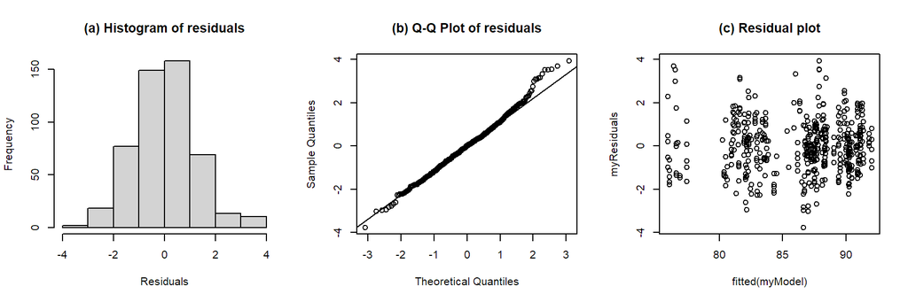

```
## Formula:  l_f0 ~ acc_phon + ana_syls + foot_syls + wrd_end_syl + pn_new_word + (1 | speaker)
##
## Linear mixed model fit by REML. t-tests use Satterthwaite's method [
## lmerModLmerTest]
## Formula: l_f0_equation
##    Data: pn_l_f0.trimmed
## Control:
## lmerControl(optimizer = optimizer, calc.derivs = FALSE, optCtrl = list(method = "nlminb",
##     starttests = FALSE, kkt = FALSE))
##
## REML criterion at convergence: 1679.2
##
## Scaled residuals:
##     Min      1Q  Median      3Q     Max
## -3.0688 -0.6423  0.0099  0.5858  3.2007
##
## Random effects:
##  Groups   Name        Variance Std.Dev.
##  speaker  (Intercept) 19.838   4.454
##  Residual              1.504   1.227
## Number of obs: 496, groups:  speaker, 11
##
## Fixed effects:
##                  Estimate Std. Error        df t value Pr(>|t|)
## (Intercept)      85.96300    1.35904  10.44202  63.253 7.74e-15 ***
## acc_phonL*       -0.17536    0.45437 475.16858  -0.386    0.700
## ana_syls1         0.91173    0.19131 475.02011   4.766 2.51e-06 ***
## ana_syls2         0.21623    0.30249 475.02916   0.715    0.475
## ana_syls3         0.07360    0.30376 475.02967   0.242    0.809
## foot_syls2       -0.10292    0.24481 475.03863  -0.420    0.674
## foot_syls3       -0.11712    0.26678 475.05542  -0.439    0.661
## foot_syls4       -0.01257    0.28864 475.04098  -0.044    0.965
## wrd_end_syl2     -0.20437    0.19243 475.04626  -1.062    0.289
## wrd_end_syl3     -0.43279    0.30492 475.05200  -1.419    0.156
## pn_new_wordTRUE  -0.75729    0.26181 475.02749  -2.892    0.004 **
## ---
## Signif. codes:  0 '***' 0.001 '**' 0.01 '*' 0.05 '.' 0.1 ' ' 1
##
## Correlation of Fixed Effects:
##             (Intr) acc_L* an_sy1 an_sy2 an_sy3 ft_sy2 ft_sy3 ft_sy4 wrd__2
```

[output cut: 33 more lines]

```
## Degrees of freedom method: Satterthwaite
##
##             Eliminated Sum Sq Mean Sq NumDF  DenDF F value    Pr(>F)
## foot_syls            1  0.611  0.2038     3 475.04  0.1354 0.9388832
## acc_phon             2  0.156  0.1560     1 478.17  0.1043 0.7469240
## wrd_end_syl          3  4.932  2.4660     2 479.07  1.6511 0.1929251
## ana_syls             0 84.909 28.3030     3 481.04 18.9008 1.328e-11 ***
## pn_new_word          0 18.448 18.4478     1 481.06 12.3195 0.0004904 ***
## ---
## Signif. codes:  0 '***' 0.001 '**' 0.01 '*' 0.05 '.' 0.1 ' ' 1
##
## Model found:
## l_f0 ~ ana_syls + pn_new_word + (1 | speaker)
##
## isSingular(my_model, tol = 1e-05 ) --> FALSE
```

Anova of model: l_f0 ~ acc_phon + ana_syls + foot_syls + wrd_end_syl + pn_new_word + (1 | speaker)

| term | sumsq | meansq | NumDF | DenDF | F value | p.value | signif. |
| --- | --- | --- | --- | --- | --- | --- | --- |
| acc_phon | 0.224 | 0.224 | 1 | 475.169 | 0.149 | 6.997102e-01 |  |
| ana_syls | 56.692 | 18.897 | 3 | 475.021 | 12.561 | 6.469900e-08 | p<0.001 |
| foot_syls | 0.611 | 0.204 | 3 | 475.038 | 0.135 | 9.388832e-01 |  |
| wrd_end_syl | 3.110 | 1.555 | 2 | 475.063 | 1.034 | 3.564898e-01 |  |
| pn_new_word | 12.587 | 12.587 | 1 | 475.027 | 8.366 | 3.997757e-03 | p<0.01 |

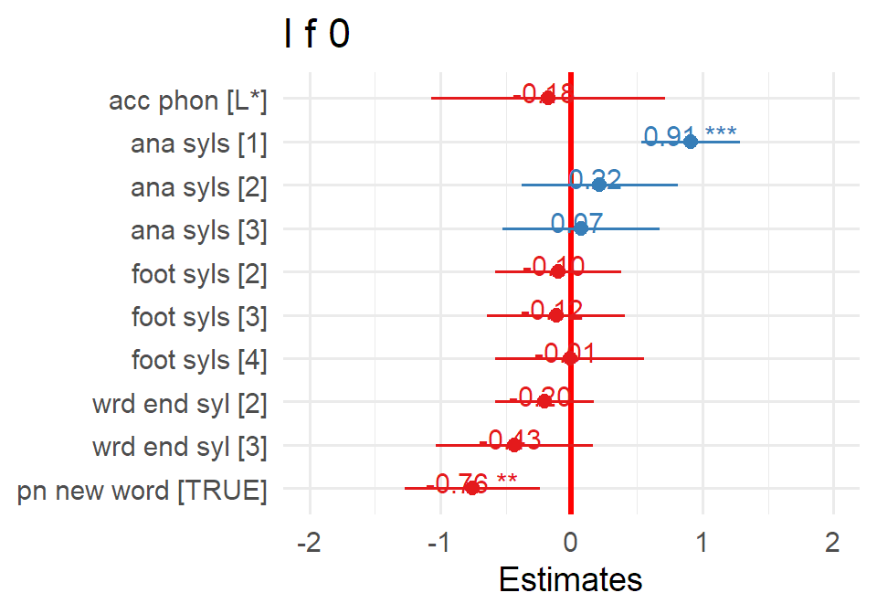

Conditional and marginal R<sup>2</sup> of model

| R2_conditional | R2_marginal |
| --- | --- |
| 0.93 | 0.01 |

$acc_phon

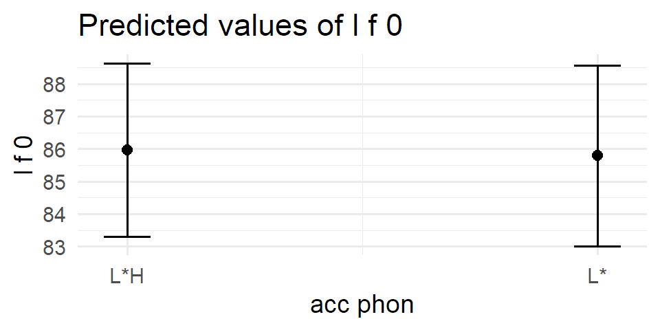

$ana_syls

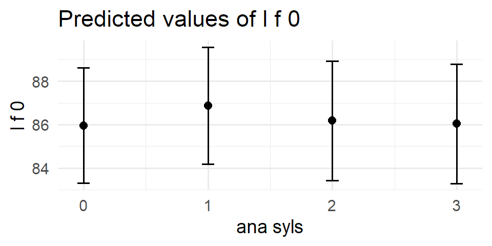

$foot_syls

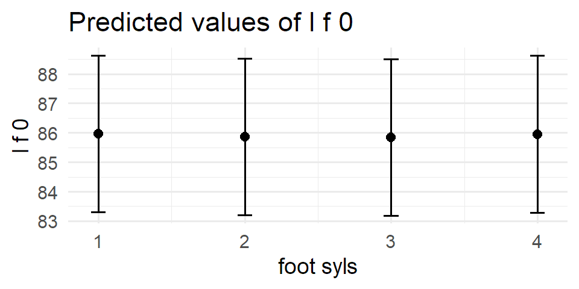

$wrd_end_syl

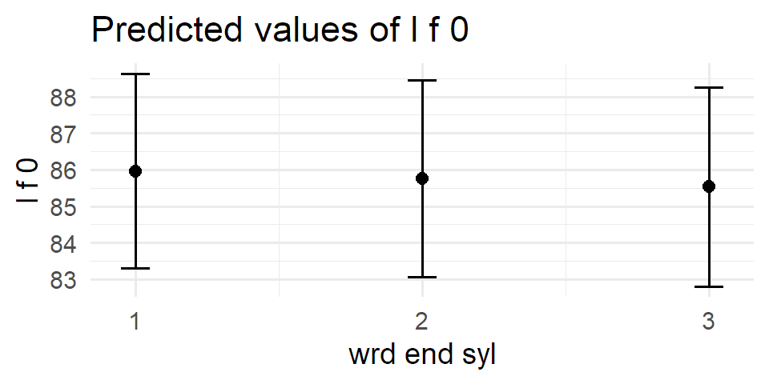

$pn_new_word

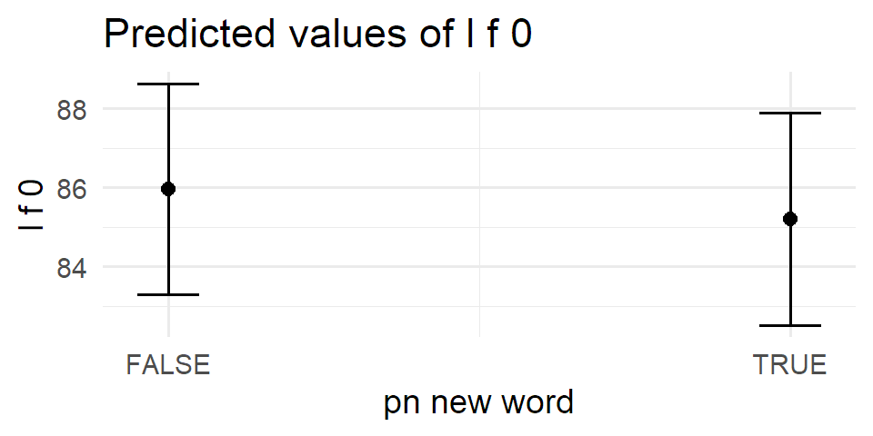

summary of model: l_f0 ~ acc_phon + ana_syls + foot_syls + wrd_end_syl + pn_new_word + (1 | speaker)

| term | estimate | conf.low | conf.high | std.error | t.value | df | p.value |
| --- | --- | --- | --- | --- | --- | --- | --- |
| (Intercept) | 85.963 | 82.9521565 | 88.9738468 | 1.359 | 63.253 | 10.44 | 7.7e-15 |
| acc_phonL* | -0.175 | -1.0681762 | 0.7174554 | 0.454 | -0.386 | 475.17 | 0.6997 |
| ana_syls1 | 0.912 | 0.5358064 | 1.2876439 | 0.191 | 4.766 | 475.02 | 2.5e-06 |
| ana_syls2 | 0.216 | -0.3781550 | 0.8106086 | 0.302 | 0.715 | 475.03 | 0.4751 |
| ana_syls3 | 0.074 | -0.5232849 | 0.6704881 | 0.304 | 0.242 | 475.03 | 0.8087 |
| foot_syls2 | -0.103 | -0.5839760 | 0.3781311 | 0.245 | -0.420 | 475.04 | 0.6744 |
| foot_syls3 | -0.117 | -0.6413321 | 0.4070935 | 0.267 | -0.439 | 475.06 | 0.6609 |
| foot_syls4 | -0.013 | -0.5797483 | 0.5546094 | 0.289 | -0.044 | 475.04 | 0.9653 |
| wrd_end_syl2 | -0.204 | -0.5824835 | 0.1737493 | 0.192 | -1.062 | 475.05 | 0.2888 |
| wrd_end_syl3 | -0.433 | -1.0319551 | 0.1663676 | 0.305 | -1.419 | 475.05 | 0.1564 |
| pn_new_wordTRUE | -0.757 | -1.2717456 | -0.2428317 | 0.262 | -2.892 | 475.03 | 0.004 |

b0 for l_f0 ~ acc_phon + ana_syls + foot_syls + wrd_end_syl + pn_new_word + (1 | speaker)

| intercept | estimate | conf.low | conf.high | std.error | t.value | df | p.value |
| --- | --- | --- | --- | --- | --- | --- | --- |
| ana_syls0 | 86 | 83 | 89 | 1.36 | 63.25 | 10.44 | 7.7e-15 |
| ana_syls1 | 86.9 | 83.8 | 89.9 | 1.37 | 63.30 | 10.86 | 2.7e-15 |
| ana_syls2 | 86.2 | 83.1 | 89.2 | 1.40 | 61.59 | 11.73 | 4.3e-16 |
| ana_syls3 | 86 | 83 | 89.1 | 1.40 | 61.48 | 11.74 | 4.3e-16 |
| foot_syls1 | 86 | 83 | 89 | 1.36 | 63.25 | 10.44 | 7.7e-15 |
| foot_syls2 | 85.9 | 82.9 | 88.9 | 1.36 | 63.23 | 10.41 | 8.5e-15 |
| foot_syls3 | 85.8 | 82.8 | 88.9 | 1.35 | 63.36 | 10.31 | 1.1e-14 |
| foot_syls4 | 86 | 82.9 | 89 | 1.37 | 62.96 | 10.63 | 5.0e-15 |
| wrd_end_syl1 | 86 | 83 | 89 | 1.36 | 63.25 | 10.44 | 7.7e-15 |
| wrd_end_syl2 | 85.8 | 82.7 | 88.8 | 1.37 | 62.51 | 10.84 | 3.2e-15 |
| wrd_end_syl3 | 85.5 | 82.5 | 88.6 | 1.39 | 61.64 | 11.34 | 1.1e-15 |

b1 for l_f0 ~ acc_phon + ana_syls + foot_syls + wrd_end_syl + pn_new_word + (1 | speaker)

| intercept | slope | estimate | conf.low | conf.high | std.error | t.value | df | p.value |
| --- | --- | --- | --- | --- | --- | --- | --- | --- |
| ana_syls0 | ana_syls1 | 0.91 | 0.536 | 1.288 | 0.190 | 4.770 | 475.02 | 2.5e-06 |
| ana_syls0 | ana_syls2 | 0.22 | -0.378 | 0.811 | 0.300 | 0.710 | 475.03 | 0.475 |
| ana_syls0 | ana_syls3 | 0.07 | -0.523 | 0.67 | 0.300 | 0.240 | 475.03 | 0.809 |
| ana_syls1 | ana_syls2 | -0.7 | -1.155 | -0.236 | 0.230 | -2.970 | 475.03 | 0.003 |
| ana_syls1 | ana_syls3 | -0.84 | -1.301 | -0.376 | 0.240 | -3.560 | 475.03 | 4.1e-04 |
| ana_syls2 | ana_syls3 | -0.14 | -0.618 | 0.332 | 0.240 | -0.590 | 475.01 | 0.556 |
| foot_syls1 | foot_syls2 | -0.1 | -0.584 | 0.378 | 0.240 | -0.420 | 475.04 | 0.674 |
| foot_syls1 | foot_syls3 | -0.12 | -0.641 | 0.407 | 0.270 | -0.440 | 475.06 | 0.661 |
| foot_syls1 | foot_syls4 | -0.01 | -0.58 | 0.555 | 0.290 | -0.040 | 475.04 | 0.965 |
| foot_syls2 | foot_syls3 | -0.01 | -0.529 | 0.5 | 0.260 | -0.050 | 475.05 | 0.957 |
| foot_syls2 | foot_syls4 | 0.09 | -0.48 | 0.66 | 0.290 | 0.310 | 475.04 | 0.756 |
| foot_syls3 | foot_syls4 | 0.1 | -0.327 | 0.536 | 0.220 | 0.480 | 475.02 | 0.634 |
| wrd_end_syl1 | wrd_end_syl2 | -0.2 | -0.582 | 0.174 | 0.190 | -1.060 | 475.05 | 0.289 |
| wrd_end_syl1 | wrd_end_syl3 | -0.43 | -1.032 | 0.166 | 0.300 | -1.420 | 475.05 | 0.156 |
| wrd_end_syl2 | wrd_end_syl3 | -0.23 | -0.698 | 0.241 | 0.240 | -0.960 | 475.08 | 0.34 |
| intercept | acc_phonL* | -0.175 | -1.068 | 0.717 | 0.454 | -0.386 | 475.17 | 0.7 |
| intercept | pn_new_wordTRUE | -0.757 | -1.272 | -0.243 | 0.262 | -2.892 | 475.03 | 0.004 |

## H targets

### Analysis of H timing

first test, step() found: `h_t ~ acc_phon + ana_syls + gender + (1 | speaker) + (1 | nuc_pre_text)`

- model needs trimming (residuals +/- 2.75 s.d.)

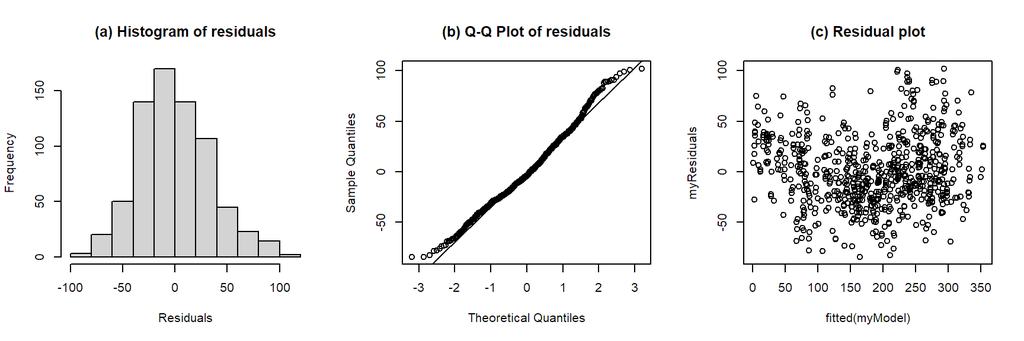

```
## Formula:  h_t ~ acc_phon + ana_syls + foot_syls + wrd_end_syl + pn_new_word + gender + (1 | speaker) + (1 | ana_text) + (1 | nuc_pre_text) + (1 | speech_rate)
##
## Linear mixed model fit by REML. t-tests use Satterthwaite's method [
## lmerModLmerTest]
## Formula: h_t_equation
##    Data: pn_h_t.trimmed
## Control:
## lmerControl(optimizer = optimizer, calc.derivs = FALSE, optCtrl = list(method = "nlminb",
##     starttests = FALSE, kkt = FALSE))
##
## REML criterion at convergence: 7155.2
##
## Scaled residuals:
##     Min      1Q  Median      3Q     Max
## -2.3383 -0.6634 -0.1155  0.6290  2.8339
##
## Random effects:
##  Groups       Name        Variance Std.Dev.
##  speech_rate  (Intercept)   81.99   9.055
##  nuc_pre_text (Intercept)  735.48  27.120
##  speaker      (Intercept)  486.07  22.047
##  ana_text     (Intercept)   88.53   9.409
##  Residual                 1293.80  35.969
## Number of obs: 714, groups:
## speech_rate, 591; nuc_pre_text, 12; speaker, 11; ana_text, 7
##
## Fixed effects:
##                 Estimate Std. Error      df t value Pr(>|t|)
## (Intercept)      232.318     30.698   5.823   7.568 0.000319 ***
## acc_phon>H*      -36.682      6.016 686.593  -6.097  1.8e-09 ***
## acc_phonH*       -74.722      4.749 694.137 -15.734  < 2e-16 ***
## ana_syls1        -35.662     30.662   4.389  -1.163 0.304121
## ana_syls2         26.891     46.529   4.726   0.578 0.589744
## ana_syls3         38.247     46.556   4.735   0.822 0.450710
## foot_syls2        23.846     31.926   4.340   0.747 0.493555
## foot_syls3        59.545     35.682   4.685   1.669 0.159961
## foot_syls4        97.636     39.005   5.584   2.503 0.049263 *
## wrd_end_syl2     -39.543     22.332  10.298  -1.771 0.106159
## wrd_end_syl3     -25.425     27.128  17.004  -0.937 0.361764
## pn_new_wordTRUE  -36.363     31.395   4.972  -1.158 0.299353
```

[output cut: 19 more lines]

```
##
##             Eliminated Sum Sq Mean Sq NumDF  DenDF  F value    Pr(>F)
## pn_new_word          1   2001    2001     1   5.14   1.4506 0.2809093
## wrd_end_syl          2   5420    2710     2  25.40   1.9646 0.1609529
## foot_syls            3   9782    3261     3   6.87   2.3544 0.1597383
## acc_phon             0 351735  175867     2 702.75 126.9798 < 2.2e-16 ***
## ana_syls             0 133923   44641     3  24.92  32.2317 9.751e-09 ***
## gender               0  39316   39316     1   9.11  28.3869 0.0004569 ***
## ---
## Signif. codes:  0 '***' 0.001 '**' 0.01 '*' 0.05 '.' 0.1 ' ' 1
##
## Model found:
## h_t ~ acc_phon + ana_syls + gender + (1 | speaker) + (1 | nuc_pre_text)
##
## isSingular(my_model, tol = 1e-05 ) --> FALSE
```

Anova of model: h_t ~ acc_phon + ana_syls + foot_syls + wrd_end_syl + pn_new_word + gender + (1 | speaker) + (1 | ana_text) + (1 | nuc_pre_text) + (1 | speech_rate)

| term | sumsq | meansq | NumDF | DenDF | F value | p.value | signif. |
| --- | --- | --- | --- | --- | --- | --- | --- |
| acc_phon | 322086.832 | 161043.416 | 2 | 687.229 | 124.473 | 7.376161e-47 | p<0.001 |
| ana_syls | 7625.875 | 2541.958 | 3 | 2.000 | 1.965 | 3.548302e-01 |  |
| foot_syls | 9285.462 | 3095.154 | 3 | 5.092 | 2.392 | 1.828300e-01 |  |
| wrd_end_syl | 5116.043 | 2558.022 | 2 | 19.716 | 1.977 | 1.649788e-01 |  |
| pn_new_word | 1735.657 | 1735.657 | 1 | 4.972 | 1.342 | 2.993533e-01 |  |
| gender | 36625.353 | 36625.353 | 1 | 9.108 | 28.308 | 4.619001e-04 | p<0.001 |

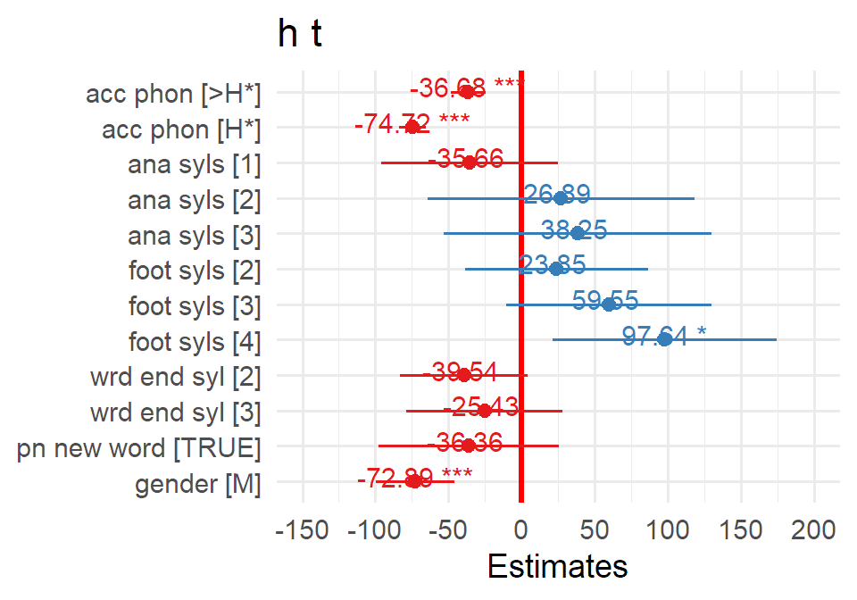

Conditional and marginal R<sup>2</sup> of model

| R2_conditional | R2_marginal |
| --- | --- |
| 0.86 | 0.71 |

$acc_phon

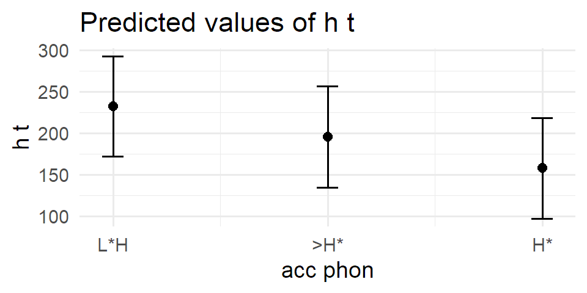

$ana_syls

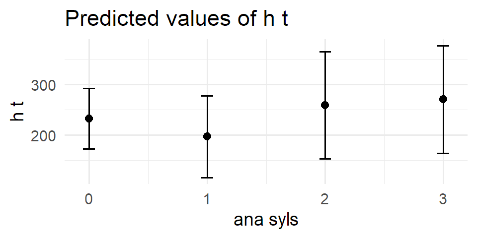

$foot_syls

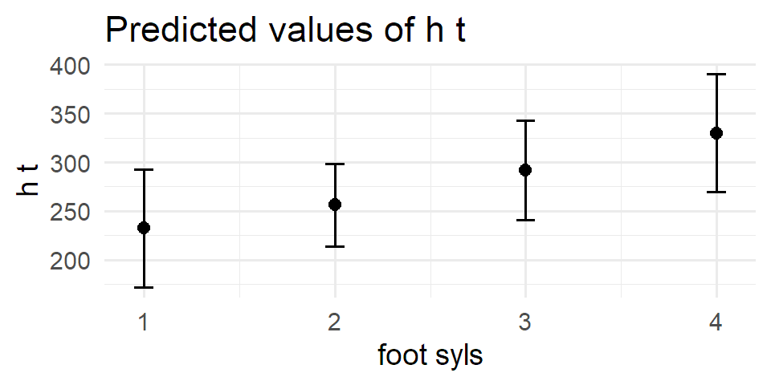

$wrd_end_syl

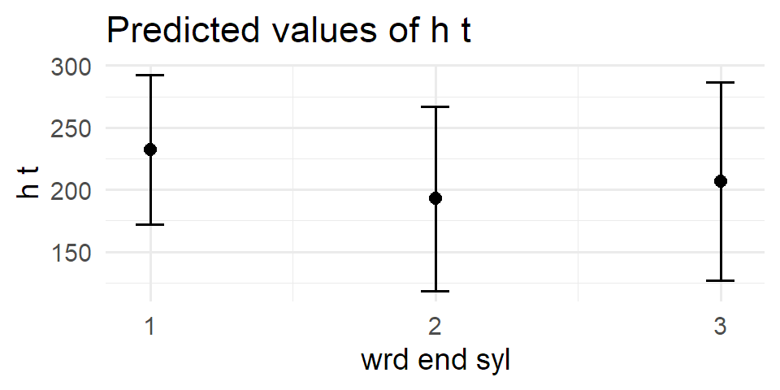

$pn_new_word

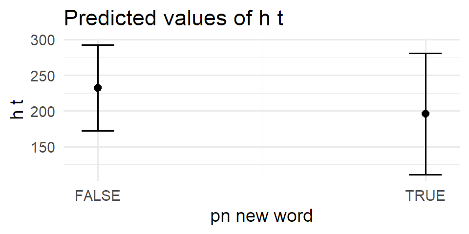

$gender

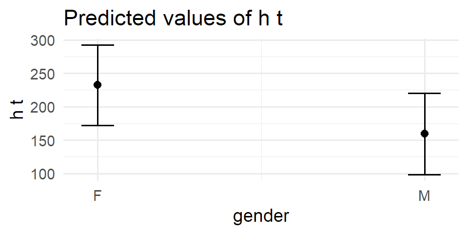

summary of model: h_t ~ acc_phon + ana_syls + foot_syls + wrd_end_syl + pn_new_word + gender + (1 | speaker) + (1 | ana_text) + (1 | nuc_pre_text) + (1 | speech_rate)

| term | estimate | conf.low | conf.high | std.error | t.value | df | p.value |
| --- | --- | --- | --- | --- | --- | --- | --- |
| (Intercept) | 232.318 | 156.6454554 | 307.99064 | 30.698 | 7.568 | 5.82 | 3e-04 |
| acc_phon>H* | -36.682 | -48.4943562 | -24.86876 | 6.016 | -6.097 | 686.59 | 1.8e-09 |
| acc_phonH* | -74.722 | -84.0461908 | -65.39756 | 4.749 | -15.734 | 694.14 | 6.2e-48 |
| ana_syls1 | -35.662 | -117.8994042 | 46.57633 | 30.662 | -1.163 | 4.39 | 0.3041 |
| ana_syls2 | 26.891 | -94.8309640 | 148.61210 | 46.529 | 0.578 | 4.73 | 0.5897 |
| ana_syls3 | 38.247 | -83.4723766 | 159.96696 | 46.556 | 0.822 | 4.73 | 0.4507 |
| foot_syls2 | 23.846 | -62.1186168 | 109.81030 | 31.926 | 0.747 | 4.34 | 0.4936 |
| foot_syls3 | 59.545 | -34.0670153 | 153.15785 | 35.682 | 1.669 | 4.68 | 0.16 |
| foot_syls4 | 97.636 | 0.4447033 | 194.82651 | 39.005 | 2.503 | 5.58 | 0.0493 |
| wrd_end_syl2 | -39.543 | -89.1070543 | 10.02144 | 22.332 | -1.771 | 10.30 | 0.1062 |
| wrd_end_syl3 | -25.425 | -82.6595623 | 31.80906 | 27.128 | -0.937 | 17.00 | 0.3618 |
| pn_new_wordTRUE | -36.363 | -117.2013429 | 44.47571 | 31.395 | -1.158 | 4.97 | 0.2994 |
| genderM | -72.891 | -103.8262028 | -41.95534 | 13.700 | -5.321 | 9.11 | 5e-04 |

```
## h_t ~ acc_phon + ana_syls + foot_syls + wrd_end_syl + pn_new_word +
##     gender + (1 | speaker) + (1 | ana_text) + (1 | nuc_pre_text) +
##     (1 | speech_rate)
```

b0 for h_t ~ acc_phon + ana_syls + foot_syls + wrd_end_syl + pn_new_word + gender + (1 | speaker) + (1 | ana_text) + (1 | nuc_pre_text) + (1 | speech_rate)

| intercept | estimate | conf.low | conf.high | std.error | t.value | df | p.value |
| --- | --- | --- | --- | --- | --- | --- | --- |
| acc_phonL*H | 232.3 | 156.6 | 308 | 30.70 | 7.57 | 5.82 | 3.2e-04 |
| acc_phon>H* | 195.6 | 120 | 271.3 | 31.15 | 6.28 | 6.18 | 6.8e-04 |
| acc_phonH* | 157.6 | 81.9 | 233.2 | 30.81 | 5.12 | 5.91 | 0.002 |
| ana_syls0 | 232.3 | 156.6 | 308 | 30.70 | 7.57 | 5.82 | 3.2e-04 |
| ana_syls1 | 196.7 | 91.9 | 301.4 | 41.29 | 4.76 | 5.23 | 0.004 |
| ana_syls2 | 259.2 | 121.7 | 396.7 | 54.46 | 4.76 | 5.32 | 0.004 |
| ana_syls3 | 270.6 | 133 | 408.1 | 54.48 | 4.97 | 5.32 | 0.004 |
| foot_syls1 | 232.3 | 156.6 | 308 | 30.70 | 7.57 | 5.82 | 3.2e-04 |
| foot_syls2 | 256.2 | 202.9 | 309.4 | 21.64 | 11.84 | 5.86 | 2.6e-05 |
| foot_syls3 | 291.9 | 230 | 353.7 | 26.08 | 11.19 | 6.90 | 1.1e-05 |
| foot_syls4 | 330 | 260.7 | 399.2 | 30.88 | 10.68 | 9.54 | 1.3e-06 |
| wrd_end_syl1 | 232.3 | 156.6 | 308 | 30.70 | 7.57 | 5.82 | 3.2e-04 |
| wrd_end_syl2 | 192.8 | 103.5 | 282 | 37.84 | 5.09 | 7.09 | 0.001 |
| wrd_end_syl3 | 206.9 | 114.2 | 299.6 | 40.79 | 5.07 | 8.76 | 7.3e-04 |

b1 for h_t ~ acc_phon + ana_syls + foot_syls + wrd_end_syl + pn_new_word + gender + (1 | speaker) + (1 | ana_text) + (1 | nuc_pre_text) + (1 | speech_rate)

| intercept | slope | estimate | conf.low | conf.high | std.error | t.value | df | p.value |
| --- | --- | --- | --- | --- | --- | --- | --- | --- |
| acc_phonL*H | acc_phon>H* | -36.7 | -48.5 | -24.9 | 6.020 | -6.100 | 686.59 | 1.8e-09 |
| acc_phonL*H | acc_phonH* | -74.7 | -84 | -65.4 | 4.750 | -15.730 | 694.14 | 6.2e-48 |
| acc_phon>H* | acc_phonH* | -38 | -50.6 | -25.5 | 6.380 | -5.960 | 673.13 | 4.0e-09 |
| ana_syls0 | ana_syls1 | -35.7 | -117.9 | 46.6 | 30.660 | -1.160 | 4.39 | 0.304 |
| ana_syls0 | ana_syls2 | 26.9 | -94.8 | 148.6 | 46.530 | 0.580 | 4.73 | 0.59 |
| ana_syls0 | ana_syls3 | 38.2 | -83.5 | 160 | 46.560 | 0.820 | 4.73 | 0.451 |
| ana_syls1 | ana_syls2 | 62.5 | -27.7 | 152.8 | 35.000 | 1.790 | 4.95 | 0.135 |
| ana_syls1 | ana_syls3 | 73.9 | -16.3 | 164.1 | 35.040 | 2.110 | 4.97 | 0.089 |
| ana_syls2 | ana_syls3 | 11.4 | -381.7 | 404.4 | 15.070 | 0.750 | 0.77 | 0.617 |
| foot_syls1 | foot_syls2 | 23.9 | -62.1 | 109.8 | 31.930 | 0.750 | 4.34 | 0.494 |
| foot_syls1 | foot_syls3 | 59.5 | -34.1 | 153.2 | 35.680 | 1.670 | 4.68 | 0.16 |
| foot_syls1 | foot_syls4 | 97.6 | 0.445 | 194.8 | 39.000 | 2.500 | 5.58 | 0.049 |
| foot_syls2 | foot_syls3 | 35.7 | -35.8 | 107.2 | 28.340 | 1.260 | 5.32 | 0.26 |
| foot_syls2 | foot_syls4 | 73.8 | -3.51 | 151.1 | 32.450 | 2.270 | 6.75 | 0.058 |
| foot_syls3 | foot_syls4 | 38.1 | -33.2 | 109.4 | 28.130 | 1.350 | 5.25 | 0.231 |
| wrd_end_syl1 | wrd_end_syl2 | -39.5 | -89.1 | 10 | 22.330 | -1.770 | 10.30 | 0.106 |
| wrd_end_syl1 | wrd_end_syl3 | -25.4 | -82.7 | 31.8 | 27.130 | -0.940 | 17.00 | 0.362 |
| wrd_end_syl2 | wrd_end_syl3 | 14.1 | -16.6 | 44.8 | 15.490 | 0.910 | 97.98 | 0.364 |
| intercept | pn_new_wordTRUE | -36.4 | -117.2 | 44.5 | 31.395 | -1.158 | 4.97 | 0.299 |
| intercept | genderM | -72.9 | -103.8 | -42 | 13.700 | -5.321 | 9.11 | 4.6e-04 |

### Analysis of H F0

first run: step() suggests: `h_f0 ~ ana_syls + foot_syls + (1 | speaker) + (1 | pn_str_syl)`

model needs trimming: residuals > 3 s.d.

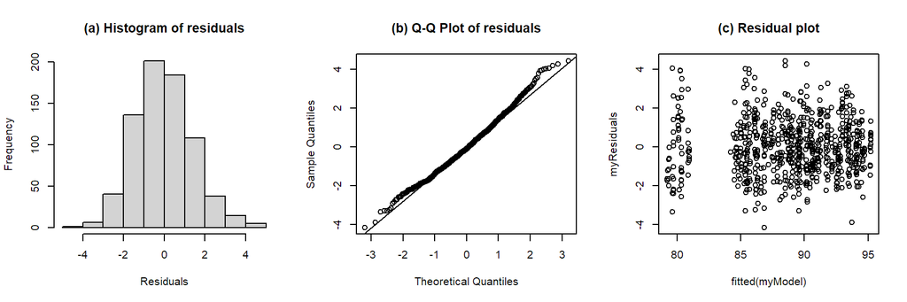

```
## Formula:  h_f0 ~ acc_phon + ana_syls + foot_syls + wrd_end_syl + pn_new_word + (1 | speaker) + (1 | pn_str_syl) + (1 | nuc_pre_text)
##
## Linear mixed model fit by REML. t-tests use Satterthwaite's method [
## lmerModLmerTest]
## Formula: h_f0_equation
##    Data: pn_h_f0.trimmed
## Control:
## lmerControl(optimizer = optimizer, calc.derivs = FALSE, optCtrl = list(method = "nlminb",
##     starttests = FALSE, kkt = FALSE))
##
## REML criterion at convergence: 2697.3
##
## Scaled residuals:
##      Min       1Q   Median       3Q      Max
## -2.89574 -0.69423 -0.07852  0.60037  3.09230
##
## Random effects:
##  Groups       Name        Variance Std.Dev.
##  nuc_pre_text (Intercept)  1.0710  1.035
##  speaker      (Intercept) 17.2112  4.149
##  pn_str_syl   (Intercept)  0.2916  0.540
##  Residual                  2.0552  1.434
## Number of obs: 733, groups:  nuc_pre_text, 12; speaker, 11; pn_str_syl, 8
##
## Fixed effects:
##                 Estimate Std. Error       df t value Pr(>|t|)
## (Intercept)      88.1013     1.7107   8.6797  51.499 4.26e-12 ***
## acc_phon>H*       0.1807     0.2310 702.9923   0.782    0.434
## acc_phonH*        0.1506     0.1824 706.2151   0.826    0.409
## ana_syls1         0.4207     1.2399   3.2005   0.339    0.755
## ana_syls2        -0.1421     1.7832   2.4949  -0.080    0.942
## ana_syls3        -0.7910     1.7844   2.5008  -0.443    0.693
## foot_syls2        0.4565     1.2641   1.8631   0.361    0.755
## foot_syls3        0.6405     1.3780   1.7504   0.465    0.693
## foot_syls4        0.3890     1.5461   2.3666   0.252    0.822
## wrd_end_syl2      1.1454     0.8829   4.7997   1.297    0.253
## wrd_end_syl3     -0.3600     1.0693   8.2828  -0.337    0.745
## pn_new_wordTRUE  -0.4282     1.3162   3.3789  -0.325    0.764
## ---
## Signif. codes:  0 '***' 0.001 '**' 0.01 '*' 0.05 '.' 0.1 ' ' 1
```

[output cut: 40 more lines]

```
## Degrees of freedom method: Satterthwaite
##
##             Eliminated Sum Sq Mean Sq NumDF  DenDF F value    Pr(>F)
## acc_phon             1  2.096  1.0482     2 705.67  0.5076 0.6021829
## pn_new_word          2  2.346  2.3460     1   2.78  1.1375 0.3698098
## wrd_end_syl          3  6.976  3.4879     2  56.54  1.6896 0.1937883
## ana_syls             0 32.748 10.9160     3 264.98  5.2478 0.0015611 **
## foot_syls            0 39.333 13.1109     3 142.69  6.3030 0.0004795 ***
## ---
## Signif. codes:  0 '***' 0.001 '**' 0.01 '*' 0.05 '.' 0.1 ' ' 1
##
## Model found:
## h_f0 ~ ana_syls + foot_syls + (1 | speaker) + (1 | pn_str_syl)
##
## isSingular(my_model, tol = 1e-05 ) --> FALSE
```

Anova of model: h_f0 ~ acc_phon + ana_syls + foot_syls + wrd_end_syl + pn_new_word + (1 | speaker) + (1 | pn_str_syl) + (1 | nuc_pre_text)

| term | sumsq | meansq | NumDF | DenDF | F value | p.value | signif. |
| --- | --- | --- | --- | --- | --- | --- | --- |
| acc_phon | 2.013 | 1.006 | 2 | 704.002 | 0.490 | 0.61307438 |  |
| ana_syls | 12.706 | 4.235 | 3 | 2.874 | 2.061 | 0.28966229 |  |
| foot_syls | 0.496 | 0.165 | 3 | 2.000 | 0.081 | 0.96462287 |  |
| wrd_end_syl | 16.075 | 8.038 | 2 | 8.975 | 3.911 | 0.06005705 |  |
| pn_new_word | 0.218 | 0.218 | 1 | 3.379 | 0.106 | 0.76405223 |  |

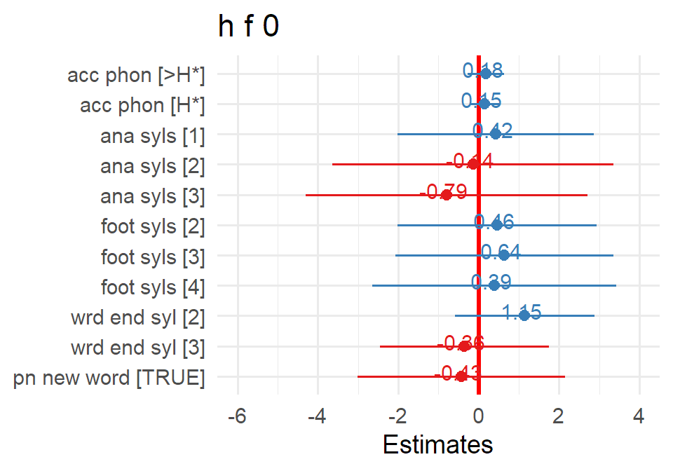

Conditional and marginal R<sup>2</sup> of model

| R2_conditional | R2_marginal |
| --- | --- |
| 0.9 | 0.02 |

$acc_phon

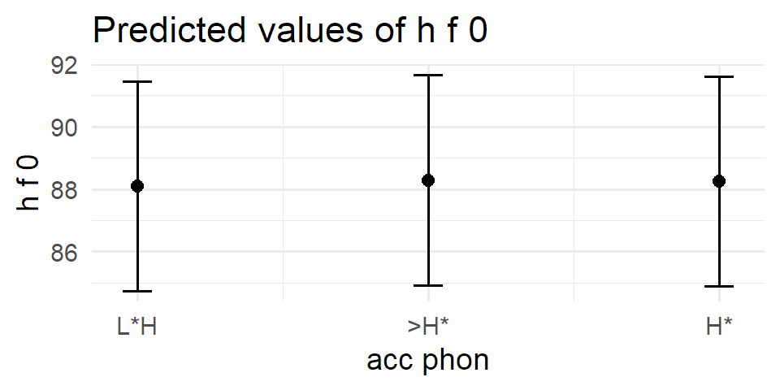

$ana_syls

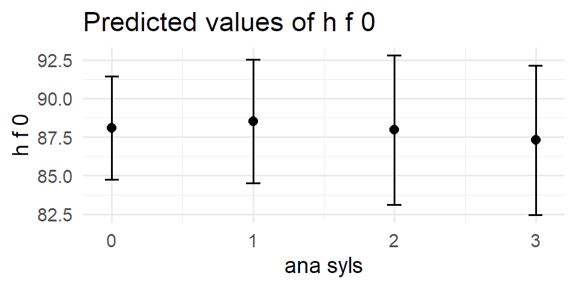

$foot_syls

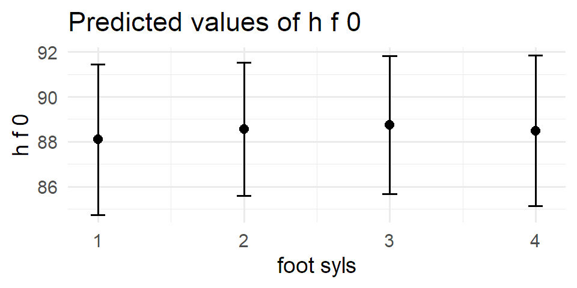

$wrd_end_syl

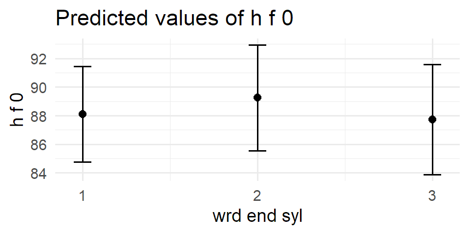

$pn_new_word

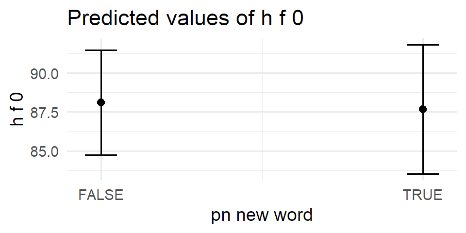

summary of model: h_f0 ~ acc_phon + ana_syls + foot_syls + wrd_end_syl + pn_new_word + (1 | speaker) + (1 | pn_str_syl) + (1 | nuc_pre_text)

| term | estimate | conf.low | conf.high | std.error | t.value | df | p.value |
| --- | --- | --- | --- | --- | --- | --- | --- |
| (Intercept) | 88.101 | 84.2094792 | 91.9930820 | 1.711 | 51.499 | 8.68 | 4.3e-12 |
| acc_phon>H* | 0.181 | -0.2728422 | 0.6343090 | 0.231 | 0.782 | 702.99 | 0.4343 |
| acc_phonH* | 0.151 | -0.2075349 | 0.5087694 | 0.182 | 0.826 | 706.22 | 0.4093 |
| ana_syls1 | 0.421 | -3.3888224 | 4.2302676 | 1.240 | 0.339 | 3.20 | 0.7554 |
| ana_syls2 | -0.142 | -6.5260601 | 6.2417771 | 1.783 | -0.080 | 2.49 | 0.9424 |
| ana_syls3 | -0.791 | -7.1680742 | 5.5861405 | 1.784 | -0.443 | 2.50 | 0.693 |
| foot_syls2 | 0.456 | -5.3837356 | 6.2966851 | 1.264 | 0.361 | 1.86 | 0.7548 |
| foot_syls3 | 0.641 | -6.1770649 | 7.4580776 | 1.378 | 0.465 | 1.75 | 0.6934 |
| foot_syls4 | 0.389 | -5.3669269 | 6.1449403 | 1.546 | 0.252 | 2.37 | 0.8215 |
| wrd_end_syl2 | 1.145 | -1.1528593 | 3.4437308 | 0.883 | 1.297 | 4.80 | 0.2534 |
| wrd_end_syl3 | -0.360 | -2.8112628 | 2.0913474 | 1.069 | -0.337 | 8.28 | 0.7448 |
| pn_new_wordTRUE | -0.428 | -4.3632585 | 3.5068748 | 1.316 | -0.325 | 3.38 | 0.7641 |

b0 for h_f0 ~ acc_phon + ana_syls + foot_syls + wrd_end_syl + pn_new_word + (1 | speaker) + (1 | pn_str_syl) + (1 | nuc_pre_text)

| intercept | estimate | conf.low | conf.high | std.error | t.value | df | p.value |
| --- | --- | --- | --- | --- | --- | --- | --- |
| acc_phonL*H | 88.1 | 84.2 | 92 | 1.71 | 51.50 | 8.68 | 4.3e-12 |
| acc_phon>H* | 88.3 | 84.4 | 92.2 | 1.72 | 51.28 | 8.91 | 2.6e-12 |
| acc_phonH* | 88.2 | 84.4 | 92.1 | 1.71 | 51.57 | 8.68 | 4.2e-12 |
| ana_syls0 | 88.1 | 84.2 | 92 | 1.71 | 51.50 | 8.68 | 4.3e-12 |
| ana_syls1 | 88.5 | 83.4 | 93.6 | 2.05 | 43.23 | 5.64 | 2.5e-08 |
| ana_syls2 | 88 | 81.2 | 94.7 | 2.47 | 35.61 | 4.13 | 2.7e-06 |
| ana_syls3 | 87.3 | 80.5 | 94.1 | 2.47 | 35.34 | 4.14 | 2.7e-06 |
| foot_syls1 | 88.1 | 84.2 | 92 | 1.71 | 51.50 | 8.68 | 4.3e-12 |
| foot_syls2 | 88.6 | 85.3 | 91.8 | 1.52 | 58.39 | 13.53 | 1.2e-17 |
| foot_syls3 | 88.7 | 85.3 | 92.2 | 1.57 | 56.64 | 12.00 | 6.1e-16 |
| foot_syls4 | 88.5 | 84.8 | 92.2 | 1.71 | 51.69 | 12.70 | 3.8e-16 |
| wrd_end_syl1 | 88.1 | 84.2 | 92 | 1.71 | 51.50 | 8.68 | 4.3e-12 |
| wrd_end_syl2 | 89.2 | 84.8 | 93.7 | 1.89 | 47.33 | 7.06 | 4.3e-10 |
| wrd_end_syl3 | 87.7 | 83.1 | 92.3 | 1.96 | 44.67 | 7.37 | 3.0e-10 |

b1 for h_f0 ~ acc_phon + ana_syls + foot_syls + wrd_end_syl + pn_new_word + (1 | speaker) + (1 | pn_str_syl) + (1 | nuc_pre_text)

| intercept | slope | estimate | conf.low | conf.high | std.error | t.value | df | p.value |
| --- | --- | --- | --- | --- | --- | --- | --- | --- |
| acc_phonL*H | acc_phon>H* | 0.18 | -0.273 | 0.634 | 0.230 | 0.780 | 702.99 | 0.434 |
| acc_phonL*H | acc_phonH* | 0.15 | -0.208 | 0.509 | 0.180 | 0.830 | 706.22 | 0.409 |
| acc_phon>H* | acc_phonH* | -0.03 | -0.509 | 0.449 | 0.240 | -0.120 | 701.32 | 0.902 |
| ana_syls0 | ana_syls1 | 0.42 | -3.389 | 4.23 | 1.240 | 0.340 | 3.20 | 0.755 |
| ana_syls0 | ana_syls2 | -0.14 | -6.526 | 6.242 | 1.780 | -0.080 | 2.49 | 0.942 |
| ana_syls0 | ana_syls3 | -0.79 | -7.168 | 5.586 | 1.780 | -0.440 | 2.50 | 0.693 |
| ana_syls1 | ana_syls2 | -0.56 | -6.275 | 5.149 | 1.310 | -0.430 | 1.97 | 0.71 |
| ana_syls1 | ana_syls3 | -1.21 | -6.917 | 4.494 | 1.310 | -0.930 | 1.97 | 0.454 |
| ana_syls2 | ana_syls3 | -0.65 | -1.186 | -0.112 | 0.270 | -2.370 | 701.14 | 0.018 |
| foot_syls1 | foot_syls2 | 0.46 | -5.384 | 6.297 | 1.260 | 0.360 | 1.86 | 0.755 |
| foot_syls1 | foot_syls3 | 0.64 | -6.177 | 7.458 | 1.380 | 0.460 | 1.75 | 0.693 |
| foot_syls1 | foot_syls4 | 0.39 | -5.367 | 6.145 | 1.550 | 0.250 | 2.37 | 0.822 |
| foot_syls2 | foot_syls3 | 0.18 | -4.231 | 4.599 | 1.140 | 0.160 | 2.25 | 0.885 |
| foot_syls2 | foot_syls4 | -0.07 | -4.207 | 4.072 | 1.310 | -0.050 | 3.03 | 0.962 |
| foot_syls3 | foot_syls4 | -0.25 | -4.514 | 4.011 | 1.130 | -0.220 | 2.33 | 0.842 |
| wrd_end_syl1 | wrd_end_syl2 | 1.15 | -1.153 | 3.444 | 0.880 | 1.300 | 4.80 | 0.253 |
| wrd_end_syl1 | wrd_end_syl3 | -0.36 | -2.811 | 2.091 | 1.070 | -0.340 | 8.28 | 0.745 |
| wrd_end_syl2 | wrd_end_syl3 | -1.51 | -2.716 | -0.295 | 0.610 | -2.480 | 68.29 | 0.016 |
| intercept | pn_new_wordTRUE | -0.428 | -4.363 | 3.507 | 1.316 | -0.325 | 3.38 | 0.764 |

## Truncation and Compression Effects

Based on results from tonal target analysis, it looks there is an element of truncation in LH contours as a function of foot size, alongside a degree of rightward drift in L targets as foot size increases. However, superficially, it looks like the slope is stable.

As with nuclear data, I am retaining the overall model structure as much as possible BUT will discard all but foot_syls for analysis.

### LH Excursion

- first run, step() suggests: `f0_exc ~ ana_syls + foot_syls + (1 | speaker) + (1 | pn_str_syl)`
- model needs trimming (|sd| residuals > 2.5)

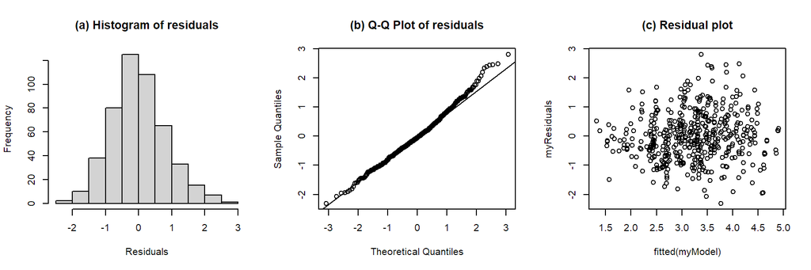

```
## Formula:  f0_exc ~ ana_syls + foot_syls + wrd_end_syl + pn_new_word + gender + (1 | speaker) + (1 | pn_str_syl) + (1 | nuc_pre_text) + (1 | speech_rate)
##
## Linear mixed model fit by REML. t-tests use Satterthwaite's method [
## lmerModLmerTest]
## Formula: f0_exc_equation
##    Data: pn_f0_exc.trimmed
## Control:
## lmerControl(optimizer = optimizer, calc.derivs = FALSE, optCtrl = list(method = "nlminb",
##     starttests = FALSE, kkt = FALSE))
##
## REML criterion at convergence: 1313.5
##
## Scaled residuals:
##     Min      1Q  Median      3Q     Max
## -2.6394 -0.6287 -0.0645  0.5703  3.2104
##
## Random effects:
##  Groups       Name        Variance  Std.Dev.
##  speech_rate  (Intercept) 3.840e-02 0.1959633
##  nuc_pre_text (Intercept) 1.229e-08 0.0001108
##  speaker      (Intercept) 1.675e-01 0.4092516
##  pn_str_syl   (Intercept) 5.641e-01 0.7510707
##  Residual                 7.637e-01 0.8739100
## Number of obs: 484, groups:
## speech_rate, 415; nuc_pre_text, 12; speaker, 11; pn_str_syl, 8
##
## Fixed effects:
##                   Estimate Std. Error         df t value Pr(>|t|)
## (Intercept)       2.171794   0.477293  14.897665   4.550 0.000389 ***
## ana_syls1        -0.006225   0.862756   4.277524  -0.007 0.994568
## ana_syls2         0.986864   0.871073   4.557546   1.133 0.313301
## ana_syls3         0.541379   0.872723   4.578025   0.620 0.564600
## foot_syls2        0.605606   0.256835 309.847888   2.358 0.018997 *
## foot_syls3        0.852694   0.248182 357.849633   3.436 0.000660 ***
## foot_syls4        0.589721   0.302540 276.860903   1.949 0.052277 .
## wrd_end_syl2      0.131857   0.187809 349.620215   0.702 0.483094
## wrd_end_syl3      0.144324   0.410658  88.351027   0.351 0.726091
## pn_new_wordTRUE  -0.778260   0.838778   4.159970  -0.928 0.404116
## genderM           0.538389   0.267120   9.193714   2.016 0.073995 .
## ---
```

[output cut: 40 more lines]

```
## Degrees of freedom method: Satterthwaite
##
##             Eliminated  Sum Sq Mean Sq NumDF  DenDF F value    Pr(>F)
## wrd_end_syl          1  0.4473  0.2237     2 128.39  0.2789  0.757103
## pn_new_word          2  0.7759  0.7759     1   4.34  0.9701  0.376341
## gender               3  3.2282  3.2282     1   9.19  4.0341  0.074870 .
## ana_syls             0 25.2693  8.4231     3 415.13 10.5305 1.092e-06 ***
## foot_syls            0 11.8173  3.9391     3 313.95  4.9246  0.002342 **
## ---
## Signif. codes:  0 '***' 0.001 '**' 0.01 '*' 0.05 '.' 0.1 ' ' 1
##
## Model found:
## f0_exc ~ ana_syls + foot_syls + (1 | speaker) + (1 | pn_str_syl)
##
## isSingular(my_model, tol = 1e-05 ) --> FALSE
```

Anova of model: f0_exc ~ ana_syls + foot_syls + wrd_end_syl + pn_new_word + gender + (1 | speaker) + (1 | pn_str_syl) + (1 | nuc_pre_text) + (1 | speech_rate)

| term | sumsq | meansq | NumDF | DenDF | F value | p.value | signif. |
| --- | --- | --- | --- | --- | --- | --- | --- |
| ana_syls | 21.873 | 7.291 | 3 | 8.946 | 9.547 | 0.003768279 | p<0.01 |
| foot_syls | 10.447 | 3.482 | 3 | 321.902 | 4.560 | 0.003815006 | p<0.01 |
| wrd_end_syl | 0.377 | 0.188 | 2 | 127.626 | 0.247 | 0.781731922 |  |
| pn_new_word | 0.657 | 0.657 | 1 | 4.160 | 0.861 | 0.404116381 |  |
| gender | 3.103 | 3.103 | 1 | 9.194 | 4.062 | 0.073995026 |  |

Conditional and marginal R<sup>2</sup> of model

| R2_conditional | R2_marginal |
| --- | --- |
| 0.59 | 0.17 |

$ana_syls

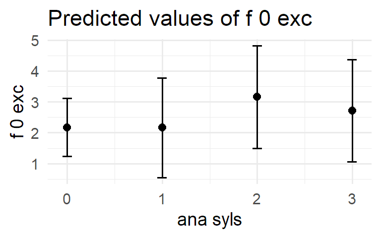

$foot_syls

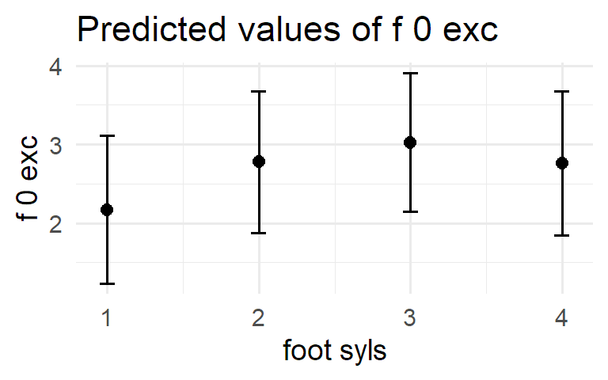

$wrd_end_syl

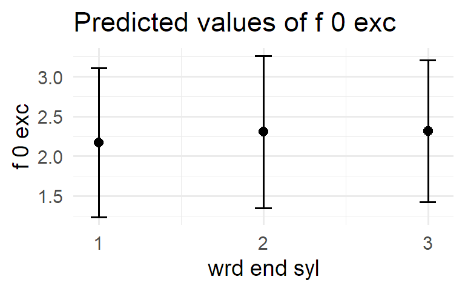

$pn_new_word

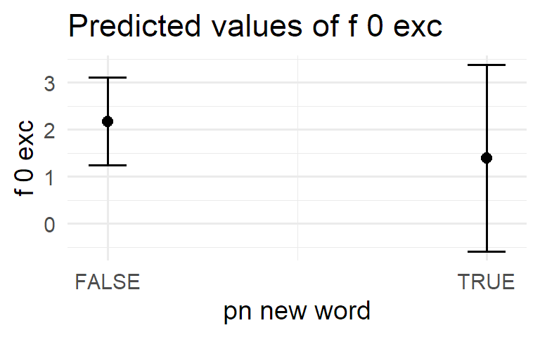

$gender

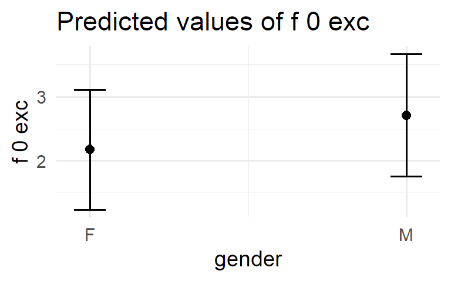

summary of model: f0_exc ~ ana_syls + foot_syls + wrd_end_syl + pn_new_word + gender + (1 | speaker) + (1 | pn_str_syl) + (1 | nuc_pre_text) + (1 | speech_rate)

| term | estimate | conf.low | conf.high | std.error | t.value | df | p.value |
| --- | --- | --- | --- | --- | --- | --- | --- |
| (Intercept) | 2.172 | 1.153857819 | 3.1897292 | 0.477 | 4.550 | 14.90 | 4e-04 |
| ana_syls1 | -0.006 | -2.341556218 | 2.3291069 | 0.863 | -0.007 | 4.28 | 0.9946 |
| ana_syls2 | 0.987 | -1.319289679 | 3.2930182 | 0.871 | 1.133 | 4.56 | 0.3133 |
| ana_syls3 | 0.541 | -1.765671779 | 2.8484297 | 0.873 | 0.620 | 4.58 | 0.5646 |
| foot_syls2 | 0.606 | 0.100244275 | 1.1109672 | 0.257 | 2.358 | 309.85 | 0.019 |
| foot_syls3 | 0.853 | 0.364614600 | 1.3407727 | 0.248 | 3.436 | 357.85 | 7e-04 |
| foot_syls4 | 0.590 | -0.005848986 | 1.1852911 | 0.303 | 1.949 | 276.86 | 0.0523 |
| wrd_end_syl2 | 0.132 | -0.237519369 | 0.5012341 | 0.188 | 0.702 | 349.62 | 0.4831 |
| wrd_end_syl3 | 0.144 | -0.671726910 | 0.9603746 | 0.411 | 0.351 | 88.35 | 0.7261 |
| pn_new_wordTRUE | -0.778 | -3.072183092 | 1.5156639 | 0.839 | -0.928 | 4.16 | 0.4041 |
| genderM | 0.538 | -0.063943595 | 1.1407214 | 0.267 | 2.016 | 9.19 | 0.074 |

b0 for f0_exc ~ ana_syls + foot_syls + wrd_end_syl + pn_new_word + gender + (1 | speaker) + (1 | pn_str_syl) + (1 | nuc_pre_text) + (1 | speech_rate)

| intercept | estimate | conf.low | conf.high | std.error | t.value | df | p.value |
| --- | --- | --- | --- | --- | --- | --- | --- |
| ana_syls0 | 2.17 | 1.154 | 3.19 | 0.48 | 4.55 | 14.90 | 3.9e-04 |
| ana_syls1 | 2.17 | 0.047 | 4.284 | 0.82 | 2.63 | 4.97 | 0.047 |
| ana_syls2 | 3.16 | 1.052 | 5.265 | 0.85 | 3.73 | 5.60 | 0.011 |
| ana_syls3 | 2.71 | 0.607 | 4.819 | 0.85 | 3.21 | 5.59 | 0.02 |
| foot_syls1 | 2.17 | 1.154 | 3.19 | 0.48 | 4.55 | 14.90 | 3.9e-04 |
| foot_syls2 | 2.78 | 1.793 | 3.762 | 0.46 | 6.06 | 13.68 | 3.2e-05 |
| foot_syls3 | 3.02 | 2.04 | 4.009 | 0.45 | 6.72 | 11.59 | 2.5e-05 |
| foot_syls4 | 2.76 | 1.752 | 3.771 | 0.47 | 5.91 | 13.04 | 5.1e-05 |
| wrd_end_syl1 | 2.17 | 1.154 | 3.19 | 0.48 | 4.55 | 14.90 | 3.9e-04 |
| wrd_end_syl2 | 2.3 | 1.268 | 3.339 | 0.49 | 4.72 | 15.70 | 2.4e-04 |
| wrd_end_syl3 | 2.32 | 1.365 | 3.267 | 0.45 | 5.10 | 18.93 | 6.5e-05 |

b1 for f0_exc ~ ana_syls + foot_syls + wrd_end_syl + pn_new_word + gender + (1 | speaker) + (1 | pn_str_syl) + (1 | nuc_pre_text) + (1 | speech_rate)

| intercept | slope | estimate | conf.low | conf.high | std.error | t.value | df | p.value |
| --- | --- | --- | --- | --- | --- | --- | --- | --- |
| ana_syls0 | ana_syls1 | -0.01 | -2.342 | 2.329 | 0.860 | -0.010 | 4.28 | 0.995 |
| ana_syls0 | ana_syls2 | 0.99 | -1.319 | 3.293 | 0.870 | 1.130 | 4.56 | 0.313 |
| ana_syls0 | ana_syls3 | 0.54 | -1.766 | 2.848 | 0.870 | 0.620 | 4.58 | 0.565 |
| ana_syls1 | ana_syls2 | 0.99 | 0.628 | 1.359 | 0.190 | 5.340 | 434.97 | 1.5e-07 |
| ana_syls1 | ana_syls3 | 0.55 | 0.183 | 0.912 | 0.190 | 2.950 | 449.93 | 0.003 |
| ana_syls2 | ana_syls3 | -0.45 | -0.795 | -0.096 | 0.180 | -2.500 | 450.89 | 0.013 |
| foot_syls1 | foot_syls2 | 0.61 | 0.1 | 1.111 | 0.260 | 2.360 | 309.85 | 0.019 |
| foot_syls1 | foot_syls3 | 0.85 | 0.365 | 1.341 | 0.250 | 3.440 | 357.85 | 6.6e-04 |
| foot_syls1 | foot_syls4 | 0.59 | -0.006 | 1.185 | 0.300 | 1.950 | 276.86 | 0.052 |
| foot_syls2 | foot_syls3 | 0.25 | -0.189 | 0.683 | 0.220 | 1.110 | 347.75 | 0.266 |
| foot_syls2 | foot_syls4 | -0.02 | -0.568 | 0.536 | 0.280 | -0.060 | 250.04 | 0.955 |
| foot_syls3 | foot_syls4 | -0.26 | -0.621 | 0.095 | 0.180 | -1.440 | 419.20 | 0.15 |
| wrd_end_syl1 | wrd_end_syl2 | 0.13 | -0.238 | 0.501 | 0.190 | 0.700 | 349.62 | 0.483 |
| wrd_end_syl1 | wrd_end_syl3 | 0.14 | -0.672 | 0.96 | 0.410 | 0.350 | 88.35 | 0.726 |
| wrd_end_syl2 | wrd_end_syl3 | 0.01 | -0.712 | 0.737 | 0.360 | 0.030 | 58.97 | 0.973 |
| intercept | pn_new_wordTRUE | -0.778 | -3.072 | 1.516 | 0.839 | -0.928 | 4.16 | 0.404 |
| intercept | genderM | 0.538 | -0.064 | 1.141 | 0.267 | 2.016 | 9.19 | 0.074 |

### LH Slope

- first run of step suggests: `log_lh_slope ~ foot_syls + gender + (1 | speaker) + (1 | nuc_pre_text)`
- Keeping all fixed effects to check effects.
- model needs trimming (|sd| residuals > 3.5)
- data needs trimming: residual SD > 4

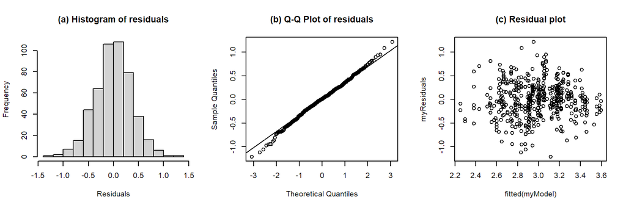

```
## Formula:  log_lh_slope ~ ana_syls + foot_syls + wrd_end_syl + pn_new_word + gender + (1 | speaker) + (1 | nuc_pre_text)
##
## Linear mixed model fit by REML. t-tests use Satterthwaite's method [
## lmerModLmerTest]
## Formula: lh_slope_equation
##    Data: pn_lh_slope.trimmed
## Control:
## lmerControl(optimizer = optimizer, calc.derivs = FALSE, optCtrl = list(method = "nlminb",
##     starttests = FALSE, kkt = FALSE))
##
## REML criterion at convergence: 492.7
##
## Scaled residuals:
##     Min      1Q  Median      3Q     Max
## -3.2157 -0.5951  0.0132  0.6284  3.2261
##
## Random effects:
##  Groups       Name        Variance Std.Dev.
##  nuc_pre_text (Intercept) 0.04955  0.2226
##  speaker      (Intercept) 0.02121  0.1456
##  Residual                 0.14166  0.3764
## Number of obs: 488, groups:  nuc_pre_text, 12; speaker, 11
##
## Fixed effects:
##                  Estimate Std. Error        df t value Pr(>|t|)
## (Intercept)      2.897613   0.244300  3.797793  11.861 0.000386 ***
## ana_syls1       -0.030115   0.230364  3.081936  -0.131 0.904059
## ana_syls2        0.132177   0.358562  3.236735   0.369 0.735210
## ana_syls3       -0.003956   0.358926  3.245570  -0.011 0.991850
## foot_syls2      -0.496992   0.271005  3.292527  -1.834 0.155803
## foot_syls3      -0.134000   0.303715  3.434431  -0.441 0.685390
## foot_syls4       0.012533   0.333177  3.816589   0.038 0.971879
## wrd_end_syl2     0.008094   0.198158  5.659187   0.041 0.968821
## wrd_end_syl3    -0.031732   0.248666  9.689304  -0.128 0.901068
## pn_new_wordTRUE  0.157200   0.250756  4.012242   0.627 0.564628
## genderM          0.269612   0.097317  9.302663   2.770 0.021091 *
## ---
## Signif. codes:  0 '***' 0.001 '**' 0.01 '*' 0.05 '.' 0.1 ' ' 1
##
## Correlation of Fixed Effects:
```

[output cut: 35 more lines]

```
## Degrees of freedom method: Satterthwaite
##
##             Eliminated  Sum Sq Mean Sq NumDF   DenDF F value  Pr(>F)
## wrd_end_syl          1 0.00992 0.00496     2 10.2882  0.0350 0.96570
## pn_new_word          2 0.06088 0.06088     1  5.3143  0.4302 0.53922
## ana_syls             3 0.71953 0.23984     3  7.1606  1.6927 0.25297
## foot_syls            0 2.24618 0.74873     3  7.1108  5.2416 0.03218 *
## gender               0 1.09984 1.09984     1  9.3187  7.6996 0.02091 *
## ---
## Signif. codes:  0 '***' 0.001 '**' 0.01 '*' 0.05 '.' 0.1 ' ' 1
##
## Model found:
## log_lh_slope ~ foot_syls + gender + (1 | speaker) + (1 | nuc_pre_text)
##
## isSingular(my_model, tol = 1e-05 ) --> FALSE
```

Anova of model: log_lh_slope ~ ana_syls + foot_syls + wrd_end_syl + pn_new_word + gender + (1 | speaker) + (1 | nuc_pre_text)

| term | sumsq | meansq | NumDF | DenDF | F value | p.value | signif. |
| --- | --- | --- | --- | --- | --- | --- | --- |
| ana_syls | 0.497 | 0.166 | 3 | 3.734 | 1.169 | 0.43103663 |  |
| foot_syls | 0.732 | 0.244 | 3 | 3.710 | 1.721 | 0.30823127 |  |
| wrd_end_syl | 0.010 | 0.005 | 2 | 10.288 | 0.035 | 0.96569715 |  |
| pn_new_word | 0.056 | 0.056 | 1 | 4.012 | 0.393 | 0.56462831 |  |
| gender | 1.087 | 1.087 | 1 | 9.303 | 7.675 | 0.02109091 | p<0.05 |

Conditional and marginal R<sup>2</sup> of model

| R2_conditional | R2_marginal |
| --- | --- |
| 0.49 | 0.23 |

$ana_syls

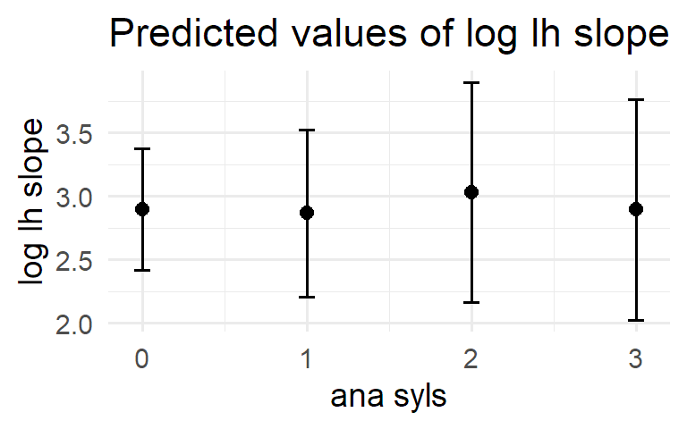

$foot_syls

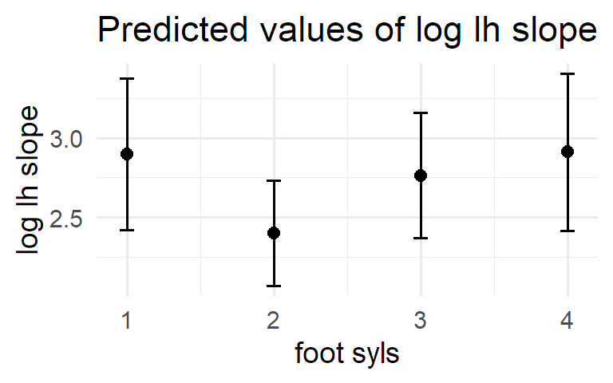

$wrd_end_syl

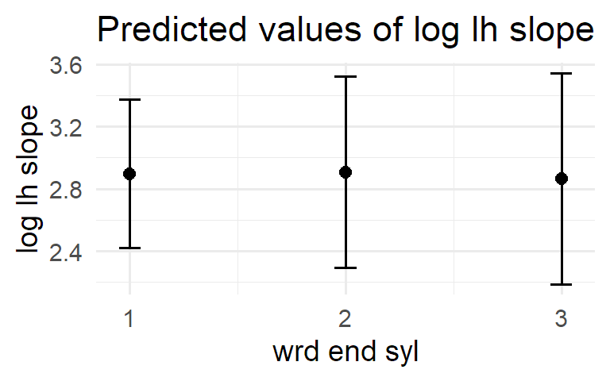

$pn_new_word

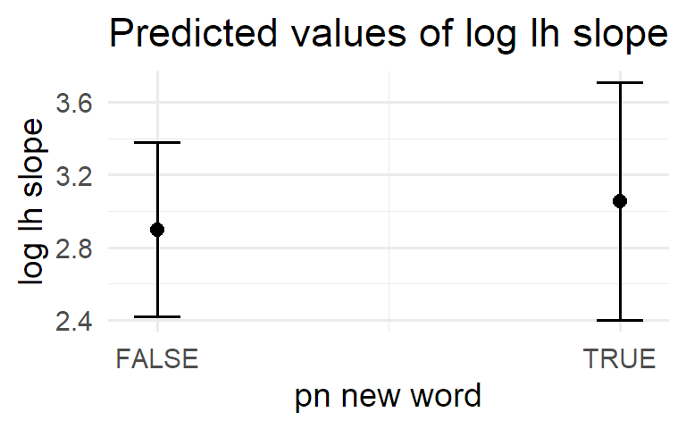

$gender

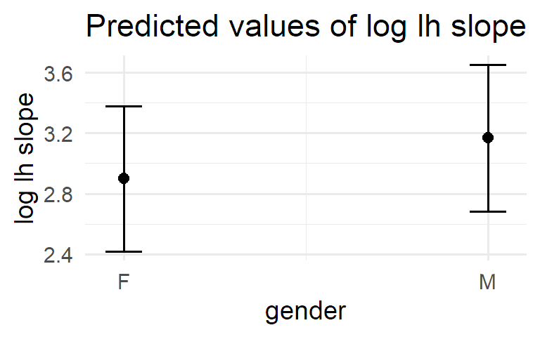

summary of model: log_lh_slope ~ ana_syls + foot_syls + wrd_end_syl + pn_new_word + gender + (1 | speaker) + (1 | nuc_pre_text)

| term | estimate | conf.low | conf.high | std.error | t.value | df | p.value |
| --- | --- | --- | --- | --- | --- | --- | --- |
| (Intercept) | 2.898 | 2.20484319 | 3.5903821 | 0.244 | 11.861 | 3.80 | 4e-04 |
| ana_syls1 | -0.030 | -0.75233145 | 0.6921012 | 0.230 | -0.131 | 3.08 | 0.9041 |
| ana_syls2 | 0.132 | -0.96313518 | 1.2274883 | 0.359 | 0.369 | 3.24 | 0.7352 |
| ana_syls3 | -0.004 | -1.09884880 | 1.0909378 | 0.359 | -0.011 | 3.25 | 0.9919 |
| foot_syls2 | -0.497 | -1.31768185 | 0.3236974 | 0.271 | -1.834 | 3.29 | 0.1558 |
| foot_syls3 | -0.134 | -1.03493970 | 0.7669396 | 0.304 | -0.441 | 3.43 | 0.6854 |
| foot_syls4 | 0.013 | -0.93031316 | 0.9553783 | 0.333 | 0.038 | 3.82 | 0.9719 |
| wrd_end_syl2 | 0.008 | -0.48394701 | 0.5001350 | 0.198 | 0.041 | 5.66 | 0.9688 |
| wrd_end_syl3 | -0.032 | -0.58821151 | 0.5247476 | 0.249 | -0.128 | 9.69 | 0.9011 |
| pn_new_wordTRUE | 0.157 | -0.53817364 | 0.8525729 | 0.251 | 0.627 | 4.01 | 0.5646 |
| genderM | 0.270 | 0.05055301 | 0.4886705 | 0.097 | 2.770 | 9.30 | 0.0211 |

b0 for log_lh_slope ~ ana_syls + foot_syls + wrd_end_syl + pn_new_word + gender + (1 | speaker) + (1 | nuc_pre_text)

| intercept | estimate | conf.low | conf.high | std.error | t.value | df | p.value |
| --- | --- | --- | --- | --- | --- | --- | --- |
| ana_syls0 | 2.9 | 2.205 | 3.59 | 0.24 | 11.86 | 3.80 | 3.9e-04 |
| ana_syls1 | 2.87 | 1.872 | 3.863 | 0.34 | 8.53 | 3.44 | 0.002 |
| ana_syls2 | 3.03 | 1.746 | 4.313 | 0.44 | 6.85 | 3.60 | 0.003 |
| ana_syls3 | 2.89 | 1.61 | 4.177 | 0.44 | 6.54 | 3.60 | 0.004 |
| foot_syls1 | 2.9 | 2.205 | 3.59 | 0.24 | 11.86 | 3.80 | 3.9e-04 |
| foot_syls2 | 2.4 | 1.998 | 2.803 | 0.17 | 14.30 | 6.55 | 3.5e-06 |
| foot_syls3 | 2.76 | 2.224 | 3.303 | 0.20 | 13.78 | 4.36 | 9.2e-05 |
| foot_syls4 | 2.91 | 2.285 | 3.536 | 0.25 | 11.54 | 5.69 | 3.7e-05 |
| wrd_end_syl1 | 2.9 | 2.205 | 3.59 | 0.24 | 11.86 | 3.80 | 3.9e-04 |
| wrd_end_syl2 | 2.91 | 2.064 | 3.747 | 0.31 | 9.27 | 4.38 | 4.8e-04 |
| wrd_end_syl3 | 2.87 | 2.003 | 3.729 | 0.35 | 8.29 | 5.53 | 2.5e-04 |

b1 for log_lh_slope ~ ana_syls + foot_syls + wrd_end_syl + pn_new_word + gender + (1 | speaker) + (1 | nuc_pre_text)

| intercept | slope | estimate | conf.low | conf.high | std.error | t.value | df | p.value |
| --- | --- | --- | --- | --- | --- | --- | --- | --- |
| ana_syls0 | ana_syls1 | -0.03 | -0.752 | 0.692 | 0.230 | -0.130 | 3.08 | 0.904 |
| ana_syls0 | ana_syls2 | 0.13 | -0.963 | 1.227 | 0.360 | 0.370 | 3.24 | 0.735 |
| ana_syls0 | ana_syls3 | -0.0e+00 | -1.099 | 1.091 | 0.360 | -0.010 | 3.25 | 0.992 |
| ana_syls1 | ana_syls2 | 0.16 | -0.662 | 0.987 | 0.270 | 0.590 | 3.35 | 0.592 |
| ana_syls1 | ana_syls3 | 0.03 | -0.798 | 0.85 | 0.280 | 0.100 | 3.36 | 0.93 |
| ana_syls2 | ana_syls3 | -0.14 | -0.282 | 0.01 | 0.070 | -1.830 | 462.60 | 0.067 |
| foot_syls1 | foot_syls2 | -0.5 | -1.318 | 0.324 | 0.270 | -1.830 | 3.29 | 0.156 |
| foot_syls1 | foot_syls3 | -0.13 | -1.035 | 0.767 | 0.300 | -0.440 | 3.43 | 0.685 |
| foot_syls1 | foot_syls4 | 0.01 | -0.93 | 0.955 | 0.330 | 0.040 | 3.82 | 0.972 |
| foot_syls2 | foot_syls3 | 0.36 | -0.321 | 1.047 | 0.250 | 1.460 | 4.10 | 0.216 |
| foot_syls2 | foot_syls4 | 0.51 | -0.242 | 1.261 | 0.280 | 1.790 | 4.61 | 0.139 |
| foot_syls3 | foot_syls4 | 0.15 | -0.536 | 0.829 | 0.240 | 0.610 | 3.76 | 0.576 |
| wrd_end_syl1 | wrd_end_syl2 | 0.01 | -0.484 | 0.5 | 0.200 | 0.040 | 5.66 | 0.969 |
| wrd_end_syl1 | wrd_end_syl3 | -0.03 | -0.588 | 0.525 | 0.250 | -0.130 | 9.69 | 0.901 |
| wrd_end_syl2 | wrd_end_syl3 | -0.04 | -0.347 | 0.267 | 0.150 | -0.260 | 41.77 | 0.795 |
| intercept | pn_new_wordTRUE | 0.157 | -0.538 | 0.853 | 0.251 | 0.627 | 4.01 | 0.565 |
| intercept | genderM | 0.27 | 0.051 | 0.489 | 0.097 | 2.770 | 9.30 | 0.021 |